# Preparatory Course: Statistics

# Data analysis I

On this first class we saw some basic definitions of statistics. Like population, sample, discrete and continuous variables, time series and a couple of graphs as examples of data visualization.

After that we learn a couple of R basics. Summarized on the following exercise:

```r
# Read de dataframe we will use from the folder Class 1 on my working directory
data = read.csv(paste0(getwd(),"//Class 1//salesdata.csv")
                          , sep=";")

#Note: here I use double // because I'm Working on a RMarkown, on a normal script I would be:
# data = read.csv("/Class 1/salesdata.csv", sep=";")
```

After having the database on the enviroment of R we can observe its structure. On this case **data** has four variables: Chanel and Impact are *character* variables meanwhile Products is a *numerical* variable and Age an *integer*.

```r
#get the structure of the data frame
str(data)
```

```
## 'data.frame':    60 obs. of  4 variables:
##  $ Channel : chr  "Online" "Online" "Online" "Direct" ...
##  $ Products: num  3.4 3.6 4.6 2.6 0.8 2.9 3.7 3.3 2.7 4.1 ...
##  $ Age     : int  2 4 6 3 4 4 4 5 4 4 ...
##  $ Impact  : chr  "Medium" "Medium" "Low" "Medium" ...
```

For each variable we produce a frequency table.

```r
#some descriptive tables
table(data$Channel)
```

```
##
## Direct Online
##     24     36
```

```r
#table(data$Products)
table(data$Age)
```

```
##
##  2  3  4  5  6
##  8 14 22 12  4
```

```r
table(data$Impact)
```

```
##
##   High    Low Medium
##     15     20     25
```

Note that de table for Products is not usefull as it is a continuos variable with very low frequencies for each one of it’s values. For this kind of variables is better to use a histogram or a boxplot.

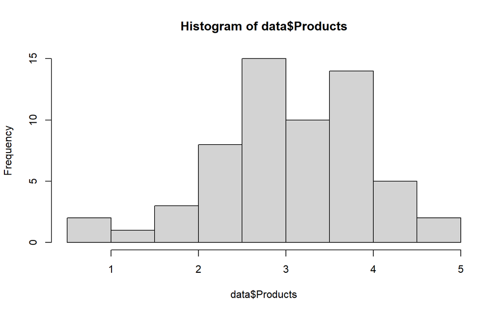

```r
#A Histogram and a Box plot
hist(data$Products)
```

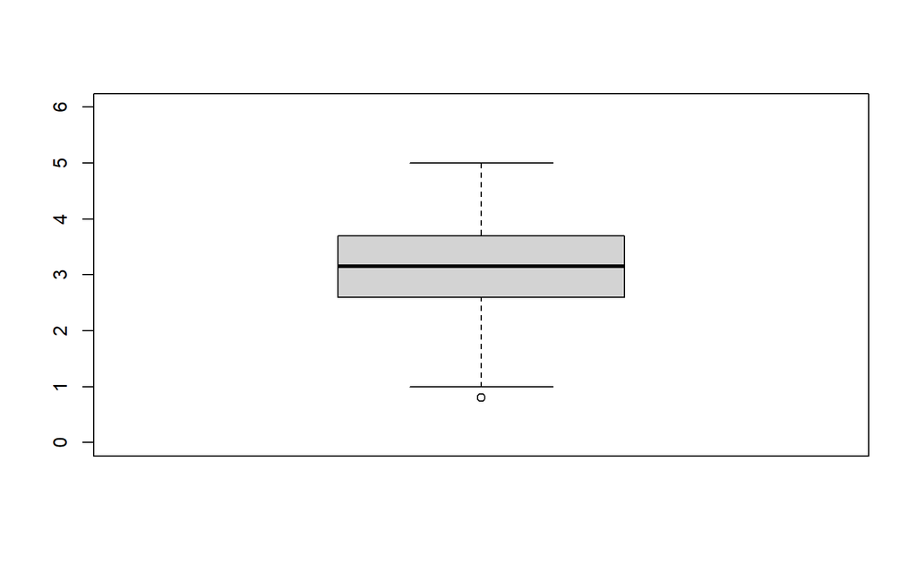

```r
boxplot(data$Products,#the data of the box plot
        ylim = c(-0,6) #option to control the y axis
        )
```

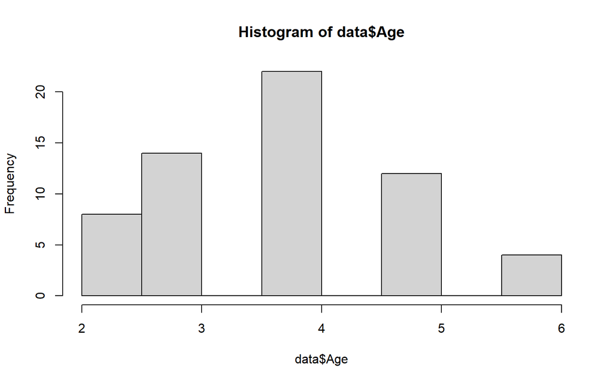

```r
# Histrogram for Age
hist(data$Age)
```

Histograms are restricted to numerical values (discrete or continuos), but a barplot is more flexible.

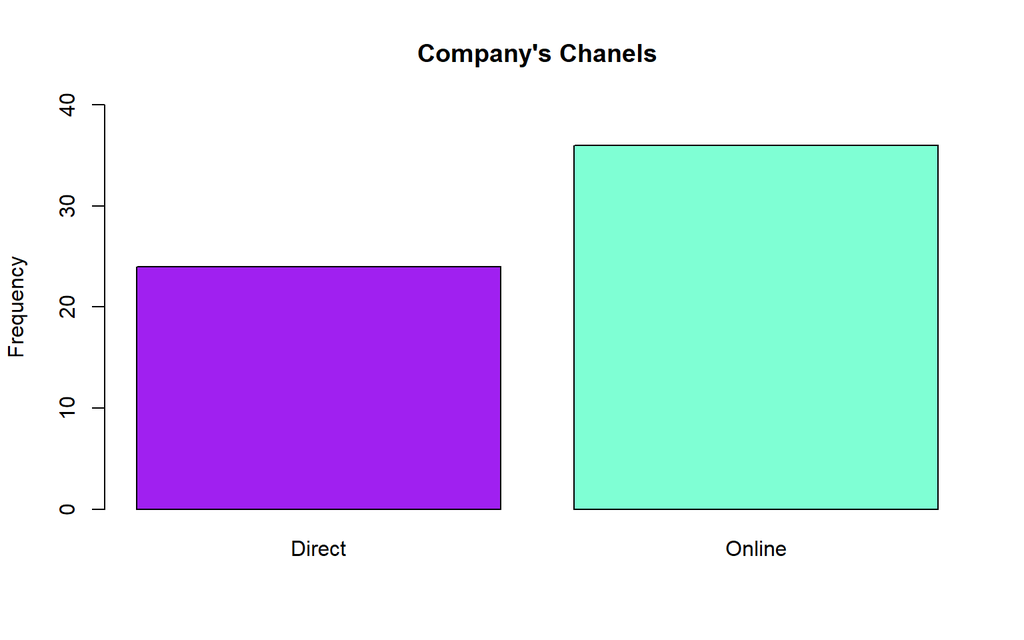

```r
#Bar plot for Channel
barplot(table(data$Channel), #the data of the bar plot
        main = "Company's Chanels", #the title
        ylim = c(0,40), #option to control the y axis
        ylab = "Frequency", #option to stablish a label for the y axis
        col = c("purple",
                "aquamarine") #option to control colors, I can use one color for all columns or define one for each on a vector
        )
```

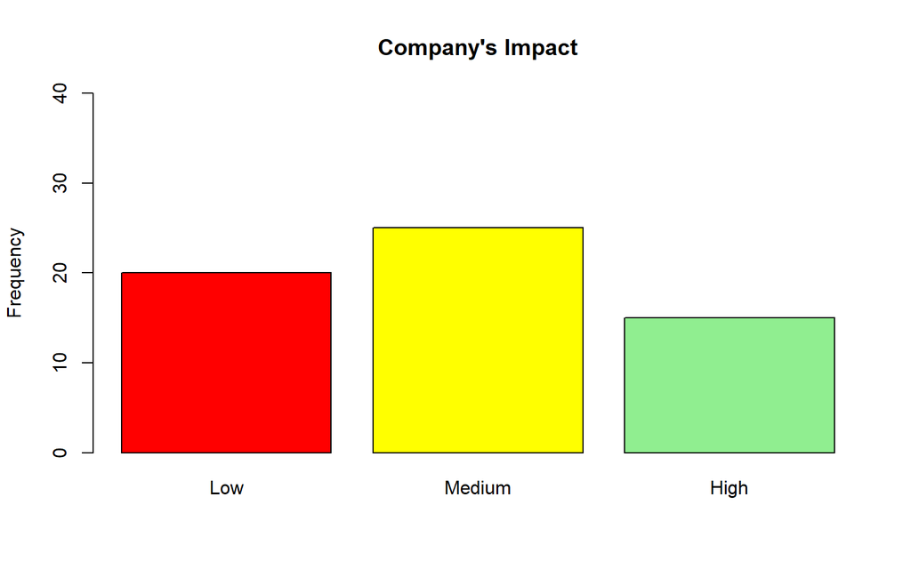

```r
#Turning Impact from character variable to a factor with three levels
data$Impact = factor(data$Impact, levels=c("Low", "Medium", "High"))

#Bar plot for Impact
barplot(table(data$Impact),
        main = "Company's Impact",
        ylim = c(0,40),
        ylab = "Frequency",
        col = c("red", "yellow", "lightgreen")
        )
```

We can configure R to show two plots at the same time

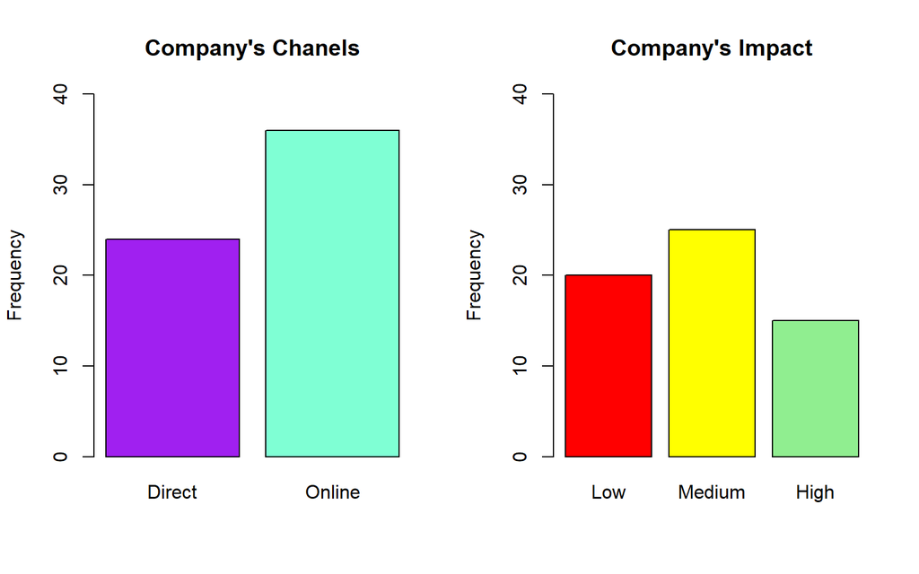

```r
#particularly we create a grid of one row and two columns
par(mfrow=c(1,2))

barplot(table(data$Channel), main = "Company's Chanels", ylim = c(0,40), ylab = "Frequency", , col = c("purple", "aquamarine"))
barplot(table(data$Impact), main = "Company's Impact", ylim = c(0,40), ylab = "Frequency", , col = c("red", "yellow", "lightgreen"))
```

```r
#this sets R permanently while we work with this environment, so if we want to come back:
#par(mfrow=c(1,1))
```

# Data analysis II

## Measures of location

1. **Mode**: Most frequent value on the set.
2. **Median**:Middle value of ordered data, robust to outliers.

$$\begin{aligned}
&\tilde{x} =
\begin{cases}
x_{(n+1)/2}, & \text{if } n \text{ is odd} \\
\dfrac{x_{n/2} + x_{(n/2)+1}}{2}, & \text{if } n \text{ is even}
\end{cases} \\[10pt]
\end{aligned}$$
3. **Percentile p**: is the value below which $p%$ of observations fall

$$Percentile_p = x_{\lceil p(n+1)/100
\rceil}$$
4. **Mean**: Arithmetic average, sensitive to outliers.

$$\bar{x} = \frac{1}{n} \sum_{i=1}^{n}
x_i$$

5. **Geometric Mean**: calculates growth over periods so it is commonly used on finance. This mean is less affected by outliers.

$$\bar x_g=\sqrt[n]{x_1x_2\ldots x_n} =
\left( \prod_{i=1}^{n}x_i \right)^{1/n}$$

## Measures of variability

As measures of dispersion we have Range ($Max-Min$), Interqualtile range ($Q_3-Q1$), Variance, Standard Deviation, and the Coefficient of Variation

1. **Variance** measures how spread out the values in a dataset are by quantifying the average squared deviation from the mean. A higher variance indicates greater dispersion, while a lower variance indicates that values are closer to the mean.

$$Var(x)=\sigma^2= s^2
=E(X^2)-E^2(X)$$
2. **Standard deviation** is the square root of the variance and represents the typical distance of observations from the mean. It is expressed in the same units as the data, which makes it easier to interpret than variance.

3. **Coefficient of variation** measures relative variability by expressing the standard deviation as a proportion of the mean. It is useful for comparing the degree of variation between datasets with different units or very different means.
4. The **z-score** (or standard score) measures how many standard deviations an observation is from the mean of the dataset. A positive z-score indicates the value is above the mean, a negative z-score indicates it is below the mean, and a z-score of zero means the value equals the mean. It is commonly used to compare observations from different distributions and to identify unusually high or low values.

$$z=\frac{x-\mu}{\sigma}$$

## Measures of dependence

As measures of dependece we can use contingency tables (which showcas joint frequencies), Covariance, or the correlation coefficient.

1. **Covariance** measures how two variables move together. A positive covariance means that when X increases, Y tends to increase; a negative covariance means that when X increases, Y tends to decrease; a covariance close to zero indicates no linear relationship.

$$Cov(X,Y)=\sigma_{X,Y}=\frac{1}{n}\sum_{i=1}^{n}(x_i-\mu_x)(y_i-\mu_y)$$
2. The **correlation coefficient**, also called pearson coefficient, standardizes covariance to a scale between −1 and 1, measuring the strength and direction of a linear relationship. Values close to 1 or −1 indicate strong positive or negative linear association, while values near 0 indicate weak or no linear relationship

$$\rho_{X,Y}=\frac{Cov(X,Y)}{\sigma_X
\sigma_Y}$$
We can apply some of these concepts on R, we’ll use the dataset already seen.

## Excerise on R

There is no way to compute the mode on R so the easiest way is to obtain a frequency table

```r
table(data$Age) #mode is 4 with 22 times on the database
```

```
##
##  2  3  4  5  6
##  8 14 22 12  4
```

To obtain most of the location measures seen we can use each function or simply `summary`

```r
#mean()
#median()

summary(data$Age) #mode is 4 with 22 times on the database
```

```
##    Min. 1st Qu.  Median    Mean 3rd Qu.    Max.
##   2.000   3.000   4.000   3.833   5.000   6.000
```

As we saw $Q_3$ is equivalent to the $Percentile_{75}$ we can prove this by

```r
quantile(data$Age, 0.75)
```

```
## 75%
##   5
```

There’s no direct function on R to compute the *geometric mean* but, we can build it

```r
prod(data$Age)^(1/length(data$Age))
```

```
## [1] 3.663462
```

```r
#this is equivalent to
exp(mean(log(data$Age)))
```

```
## [1] 3.663462
```

For measures of dependence we can compute:

```r
#covariance
cov(data$Products, data$Age)
```

```
## [1] 0.5183616
```

```r
#correlation coefficient
cor(data$Products, data$Age)
```

```
## [1] 0.5474521
```

We can also compute some indexes for several variables at a time or several observations (rows) at a time:

```r
#mean of columns
colMeans(data[,c(2,3)]) #we use the subset of the secxont and third variables because they are numeric
```

```
## Products      Age
## 3.108333 3.833333
```

```r
#mean of row
rowMeans(t(data[,c(2,3)])) #we use the function t to transpose
```

```
## Products      Age
## 3.108333 3.833333
```

# Elements of Probability

We defined a random experiment, Sample Space and Event including: intersection, mutually exclusive events, union and complementary events.

## Permutations and combinations

A **permutation** *(P)* is the total number of sets I can get from *n* elements when I form groups of *k* elements. The order of the elements on the group matters (AB is not equal to BA)

$$P_k^n=\frac{n!}{(n-k)!}$$
A **combination** *(C)* is the total number of sets I can get from *n* elements when I form groups of *k* elements, but the order does not matter (so AB is equal to BA)

$$C_k^n=\frac{P_k^n}{k!}=\frac{n!}{k!(n-k)!}=\begin{pmatrix}
n\\
k
\end{pmatrix}$$

## Probability

Probability is the chance that an event will occur, ranges from 0 to 1 (0% to 100%).

Some probability axioms are: If $0\le Pr(A)\le 1$, $Pr(S)=1$, and every event is mutually disjoint, then:

$$Pr(\bigcup_{i=1}^{n}A_i)=\sum_{i=1}^{n}Pr(A_i)$$
Addition rule: $Pr(A\cup B)=Pr(A)+Pr(B)-Pr(A\cap B)$

Difference rule: $Pr(A-B)=Pr(A)-Pr(A\cap B)$

### Interpretation of probability

- **Classical probability**: is the proportion of times that an event will occur, assumint that all outcomes in sample space are *equally likelly* (so, like a mean)

$$Pr(A)=\frac{N_A}{N}$$

- **Relative frequency probability**: is the limit of the proportion of times that event A occurs in a large number of trials.

$$Pr(A)=\lim_{n\rightarrow\infty}\frac{n_A}{n}$$

- **Subjective Probability**: expresses an individual opinion or belief the change that an event will occur. For example I think that tomorrow there is a 90% chance it will be sunny. It’s the underlying interpretation behind Bayesian theory.

### Conditional probability

Defined as the chance that an event (A) will occur given that (B) has occurred. For example, we know for certain tomorrow will be rainy (B) therefore probably will be cold (A).

$$Pr(A|B)=\frac{Pr(A\cap
B)}{Pr(B)}$$
Multiplication rule: $Pr(A\cap B)=Pr(A|B)Pr(B)$ or $Pr(A\cap B)=Pr(B|A)Pr(A)$.

Statistical independece (or stochastic independece) occurs when the conditional probability of event A, given event B, is the same of the unconditional probability of A (meaning, B does not affect the occurrence of A). It follows the subsequent motification to the multiplication rule:

Multiplication rule (for independent events): $Pr(A\cap B)=Pr(A)Pr(B)$

### Bayes Theorem

Let’s consider a *partition* ($B_i$) which is the decomposition of the sample space S into a collection of mutually exclusive event.

The **theorem of total probability** states that:
$$Pr(A)=\sum_{i=1}^{n}{Pr(A|B_i)Pr(B_i)}$$
Considering two events, the Bayes Theorem states:
$$Pr(A|B)=\frac{Pr(B|A)Pr(A)}{Pr(B)}$$
Now, if we combine both theorems:
$$\begin{split}
Pr(B_j|A)&=\frac{Pr(A|B_j)Pr(B_j)}{Pr(A)} \\
&= \frac{Pr(A|B_j)Pr(B_j)}{\sum_{i=1}^{n}{Pr(A|B_i)Pr(B_i)}}
\end{split}$$

# Discrete variables

A **random variable** (X, Y, Z, f(x), etc) is a set of numerical values we assign to the outcomes of a randome experiment. if $X=\{x_1,x_2,...,x_N\}$ is the random variable, $N$ is the total number of observations and $X_i$ is de $i$ value. Random variables are numerical but they can be Discrete or Continuos.

A *discrete random variable* takes finite of countable number of values (normaly integers), a *continuos random variable* takes an infinite number of values in any interval.

## Probability Distributions

The *probability mass function (pmf)* $Pr(X)=f(x)$ of a discrete random variable $X$, represents the chance that $X$ takes de value $x$.

$$Pr(x)=Pr(X=x) \text{ for each value of
}x$$

The *pmf* of a discrete variable must be positive and equal or less than one, and the sum in all the domain of X most be equal to one (sum of all sample space).

But many times, we are not interested in knowing the chance of one particular event (value), but the chance of getting a set of events. For this we use the *cumulative distribution function (cdf)* defines as the chance that $X$ takes any valie smaller or equall than $x_i$

$$\begin{split}F(x_i) &= Pr(X\le x_i)
\\
&= \sum_{x\le x_i}Pr(x) \end{split}$$

The *cdf* of a discrete random variable must be contained on the closed interval $[0,1]$ and if ginven two values of X such as $x_0\le x_1$, it must satisfy: $F(x_0)\le F(x_1)$.

The *expected value* of a discrete random variable X is defines by

$$E(X)=\mu=\sum_{x}xPr(x)$$
so we can see the expected value is equivalent to the weighted average of the random variable, where the weights are the probability of each value.

The *variance* of a discrete random variable is defined as

$$V(X)=\sigma^2=E(X^2)-E(X)^2$$
Therefore the *standard deviation* is denoted by $\sigma$

## Binomial Distribution

Let’s say for example that $X$ is a variable that distributes as a bernoulli process (has *bernoulli distribution*) X can have to results, success denoted by 1 with probability $p$ and failure denoted by 0 with chance $1-p$.

$$X \thicksim Ber(p) \\
X=1 \text{ if succes} \\
X=0 \text{ if failure}$$

This means that the pmf of bernoulli is:

$$f(x)=Pr(X=x)=p^x(1-p)^{1-x} \\
E(X)=\mu_x=\sum_x xf(x)=p \\
Var(X)=\sigma_{x}^{2}=E[(X-\mu_x)^2]=p(1-p)$$

The *binomial distribution* can be interpreted as the repetition of many independent bernoulli processes by $n$ times. So $Y$ is the random variable that denotes the repetition of the Bernoulli process given by $X\thicksim Ber(p)$.

$$Y \thicksim Bin(n,p) \\
f(Y)=Pr(Y=y)=\begin{pmatrix}
n\\
k
\end{pmatrix}p^y(1-p)^{n-y} \\
E(Y)=\mu_y=np \\
Var(Y)=\sigma_{y}^{2}=np(1-p)$$

In R there are four functions to compute a binomial distribution:

- rbinom function is randomly drawing a distribution
- dbinom density or probability mass function pmf f(x)
- pbinom cumulative mass function cmf F(x)
- qbinom computes a quantile, is the inverse function of pbinom.

We will define a variable $X$ with binomial distribution, probability of success $p=0.5$

```r
n=10 #we define the size of the experiment
p=0.5 # probability of success

#we create a vector, each elemnt es the numbers of succeses I got on each draw
rbinom(n=100, #the number of observations a draw from the distribution
       size=n,
       prob=p)
```

```
##   [1] 6 4 7 4 5 4 5 4 4 4 5 3 5 3 7 7 4 4 4 8 4 5 5 6 4 6 7 4 5 2 8 5 6 3 6 9 4
##  [38] 1 3 6 7 3 5 5 7 6 6 3 7 4 6 6 3 7 6 7 3 4 4 2 6 7 7 3 4 8 5 4 4 4 6 5 4 6
##  [75] 3 3 4 5 6 6 6 5 5 6 5 5 4 4 5 3 5 6 4 4 2 4 6 5 4 4
```

```r
#compute the probability of x=5 (out of 10 trials) -> f(X=5) -> pmf
dbinom(x = 5,
       size = n,
       prob = p)
```

```
## [1] 0.2460938
```

```r
# to 'manually compute the probability mass function
probs= dbinom(x = 0:10,
       size = n,
       prob = p)

probs
```

```
##  [1] 0.0009765625 0.0097656250 0.0439453125 0.1171875000 0.2050781250
##  [6] 0.2460937500 0.2050781250 0.1171875000 0.0439453125 0.0097656250
## [11] 0.0009765625
```

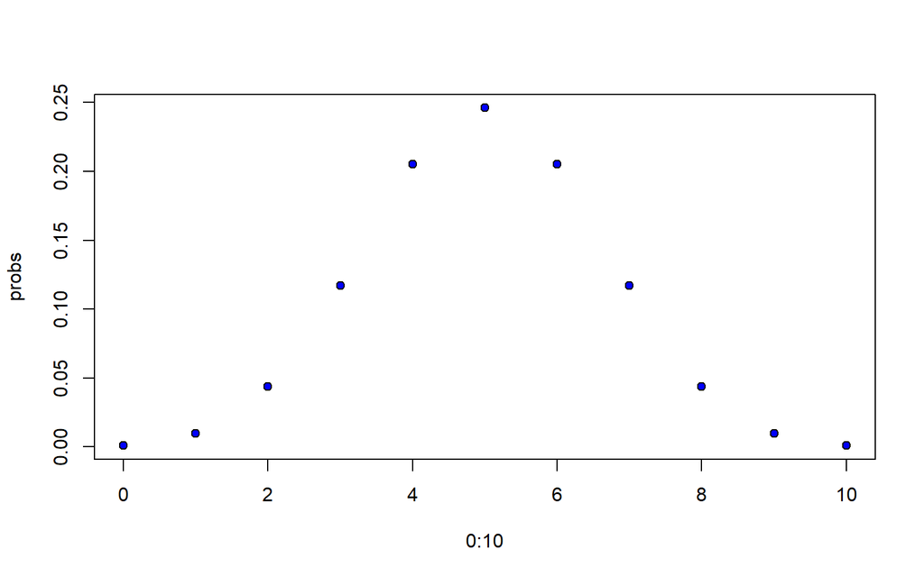

```r
#lets plot probs
plot(0:10, probs,
     pch=21, #type of graph: filled points
     col="black", #color of the border of points
     bg="blue" #color to fill the points
     )
```

Now we want to compute $Pr(x\leq 2)$, on other word we search for the value of the cumulative function from 0 to 2

```r
#"manually"
sum(dbinom(x = 0:2, size = n,prob = p)) #we sum the probability of each value
```

```
## [1] 0.0546875
```

```r
#automated
pbinom(2, size = n, prob = p)
```

```
## [1] 0.0546875
```

Now we can look for the corresponding quantile function

```r
qbinom(p=0.054, size=n, prob = p)
```

```
## [1] 2
```

## Hypergeometric distribution

Describes the number of successes in $n$ dependent Bernoulli trials. We asume that the initial size of the experiment $N$ decreases after each repetition. We say then than $X$ has a *hypergeometric distribution* with parameters $N$, $M$, $n$. Where $M$ is the numbers of elements with successes.

$$X\thicksim Hyper(N, M, n) \\
f(x)=Pr(X=x)=\frac{C_x^M C_{n-x}^{N-M}}{C_n^N}$$

## Poison distribution

For a variable to have a Poisson distribution, it must satisfy the followin conditions: - The prob. of ocurrence of an event is constant for all classes. - There can be no more than one ocurrence in each class. - Ocurrences are independent

On easy words: this distributions models the number of times than a determined event occurs on a continuos interval of space or time. For example the number of calls recieved on an hour by a call center.

Let’s say $X$ dsitributes Poisson with parameter $\lambda$, this parameters represent the expected number of ocurrences per time or area unit.

$$X\thicksim Pois(\lambda) \\
f(x)=Pr(X=x)=\frac{e^{-\lambda}\lambda^x}{x!} \\
E(X)=\mu_x=\lambda \\
Var(X)=\sigma_{x}^{2}=\lambda$$

On R this is

```r
#set the parameter
lambda = 0.09

#manually computing the f(x=0)
exp(-lambda)*lambda^0/factorial(0)
```

```
## [1] 0.9139312
```

```r
#using the function to compute f(x=0)
dpois(x=0, lambda=0.09)
```

```
## [1] 0.9139312
```

```r
#we comprobe both are equals
exp(-lambda)*lambda^0/factorial(0)==dpois(x=0, lambda=0.09)
```

```
## [1] TRUE
```

```r
#now if we want two know f(x<=1)=F(x=1)
(exp(-lambda)*lambda^0/factorial(0))+(exp(-lambda)*lambda^1/factorial(1))
```

```
## [1] 0.996185
```

```r
#we can also compute with the function
ppois(q=1, lambda = 0.09)
```

```
## [1] 0.996185
```

```r
#Note that for discrete variables F(x=2)=f(x>=2)=1-f(x<=1) so if we want to compute F=(2)
1-ppois(q=1, lambda = 0.09)
```

```
## [1] 0.003815008
```

Let’s draw a Poisson distribution

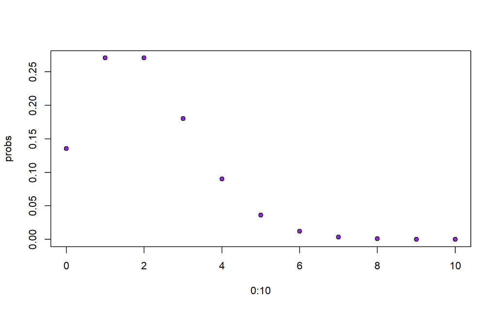

```r
# parameter is 2, pmf for each value from 0 to 10.
probs=dpois(x=0:10, lambda=2)

#lets plot probs
plot(0:10, probs,
     pch=21, #type of graph: filled points
     col="black", #color of the border of points
     bg="purple" #color to fill the points
     )
```

## Joint probability distributions

if $X$ and $Y$ are discrete random variables. Their joint probability distribution represent the chance that simultaneously $X$ takes the value $x$ while $Y$ takes the value $y$ (intersection of events).

$$f(x,y)=Pr(x,y)=Pr(X=x\text{ }\cap\text{
}Y=y)$$
the *marginal probability function of X* represent the probability of X for all the possible values of Y.The marginal probability function of Y is analogous.

$$Pr(x)=g(x)=\sum_yPr(x,y)$$
On the other hand the *conditional probability distribution* represents the chance of a variable taking a certain value, while there is an underlying fixed value for the secondary variable.

$$Pr(Y=y|X=x_0)=\frac{Pr(x_0,y)}{Pr(x)}=\frac{f(x_0,y)}{g(x)}$$
Two jointly distributed random variables $X$ and $Y$ are independent if and only if their joint distribution can be written as the product of their marginal distributions.

$$Pr(x,y)=Pr(x)Pr(y)$$

The *conditional mean* of $Y$ given $X$ is defines as
$$\mu_{Y|X}=E(Y|X)=\sum_{y}yPr(y|x)$$
As a consequence, the *conditional variance* of $Y$ given $X$ is defines as:
$$\sigma_{Y|X}^{2}=E[(Y-\mu_{Y|X})^2|X]=\sum_y(y-\mu_{Y|X})^2Pr(y|x)$$
The *covariance* allows us two measure the linear association between two variables. If they are independent the covariance will be 0, yet the converse is not necessarily true.

$$Cov(X,Y)=E[(X-\mu_X)(Y-\mu_Y)]=E(XY)-E(X)E(Y)=\sum_x
\sum_y xyPr(x,y)-\mu_X \mu_Y$$
As we saw before the *correlation coefficient* measures the linear correlation, this coefficient is restricted to the interval [-1,1].

$$\rho_{X,Y}=Corr(X,Y)=\frac{Cov(X,Y)}{\sigma_X\sigma_Y}$$
This measures of dependence can be 0 because the linear dependence is 0, but this doesn’t mean they are stochastically (statistically) independent, as they could -for example- have a quadratic relation (non linear).

*Note: iid means independent and identically distributed*

# Continuous Variables

If a variable is continuos we have that $Pr(X=x)=0$, because the sample space is so large relatively a particular value. Therefore the chance of any particular value is vanishingly small (tends to 0).

Consequently, we will need different definitions than those we used for discrete variables.

## Probability Distributions

The **probability density function (pdf)** is not the representation of a probability, we can think of it a the limit of a relative frequency histrogram for many realisations of the random quantity. A *pdf* satisfies the following conditions:

- $f(x)\ge 0$
- $\int^{\infty}_{-\infty}f(x)dx=1$
- $Pr(a\le X \le b)=\int^{b}_{a}f(x)dx$
- $Pr(X\le x) = Pr(X< x)$

The **cumulative distribution function (cdf)** will be the probability of X being smaller or equal than a particular vallue, and it corresponds to the integral of the pdf.

$$F(x_0)=Pr(X\le x_0)=f(X\le
x_0)=\int^{x_0}_{-\infty}f(x)dx$$
The expected value and variance of a continuous probability distribution are defined by

$$\mu_x=E(X)=\int^{\infty}_{-\infty}xf(x)dx \\
\sigma_x^2=V(X)=\int^{\infty}_{-\infty}(x-\mu_x)^2f(x)dx$$

## Uniform distribution

The random variable $X$ has a uniform distribution over the range $[a,b]$ its pdf and cdf are given by

$$X\thicksim U(a,b)$$

$$f(x)= \begin{cases} \frac{1}{b-a} &
a\le x \le b \\
0 & \text{otherwise} \end{cases}$$

$$F(x)= \begin{cases} 0 & x < a \\
\frac{x-a}{b-a} & a\le x \le b \\
1 & x>b \\ \end{cases}$$

Let’s imagine that $X\thicksim U(2,6)$ its pdf and cdf would look like:

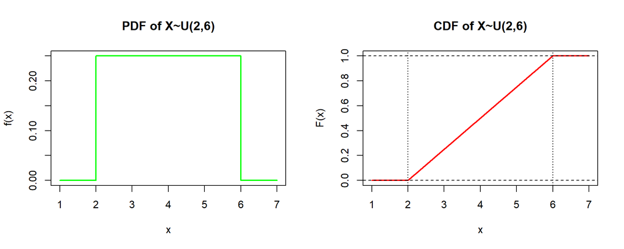

Meanwhile its expectation and variance are given by

$$\mu_x=\frac{a+b}{2}=4 \\
\sigma_x^2=\frac{(b-a)^2}{12}=\frac{16}{12}=1.3$$

## Exponential distribution

A random variable $X$ is *xponentially distributed* with parameter $\lambda$ when its pdf and cdf are given by:

$$X\thicksim exp(\lambda) \\
f(x)= \begin{cases} \lambda e^{-\lambda x} & x \ge 0 \\
0 & \text{otherwise} \end{cases} \\
F(x)= \begin{cases} 0 & x < 0 \\
1-e^{-\lambda x} & x \ge 0 \end{cases}$$

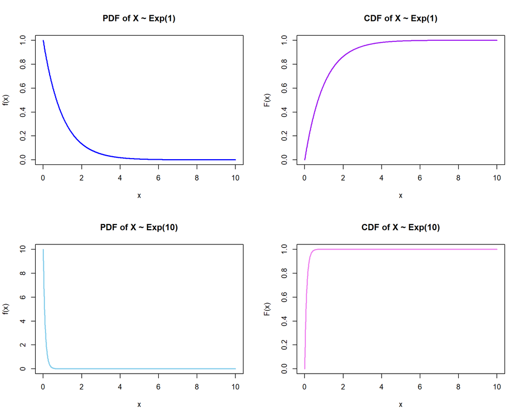

We can understand the exponential distribution as the inverse of the Poisson distribution. So it represents, for example, the amount of time it takes to recieve a call on a callcenter.

## Normal Distribution

The normal distribution is important in statisticks because we can apply it to a broad number of escenarios. We will say $X$ has a *normal o Gaussian distribution* with parameters $\mu$ and $\sigma^2$ wich are the expected value and variance respectively.

$$X\thicksim N(\mu , \sigma^2) \\
E(X)=\mu \\
Var(X)=\sigma^2$$

The normal distribution is centered on its mean wich mean, median, mode and mean coincide.

[figure not shown]

### Standard Normal Distribution

This is a particular case of a normal distribution where $\mu=0$ and $\sigma^2=1$

$$Z\thicksim N(0, 1)$$
knowing the standard normal distribution is usefull because the values for the CDF ($\Phi(z)$) are already known (on a table), and we can standarize any normal distribution.

A variable $X\thicksim N(\mu , \sigma^2)$ can be standarized to Z with the following:

$$z=\frac{x-\mu}{\sigma} \thicksim
N(0,1)$$

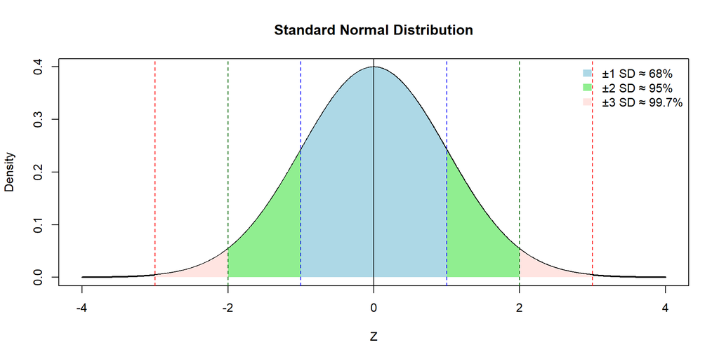

We can easily plot a normal distribution on R using the function `plot`

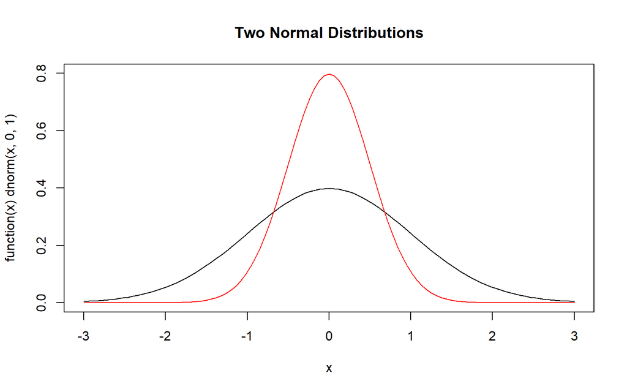

```r
#we don't need to create al the distribution, but only indicate the function
plot(function(x) dnorm(x, 0, 1), from=-3, to=3, ylim=c(0,0.8), main = "Two Normal Distributions")
plot(function(x) dnorm(x, 0, 0.5), from=-3, to=3, ylim=c(0,0.8), col="red", add=TRUE)
```

### Normal approximation of the binomial

if $X\thicksim Bin(n,p)$, then if n is large and p is not extreme the variable can be approximated by a normal distribution

$$X\approx N(np, np(1-p))$$
We can check this using graphs:

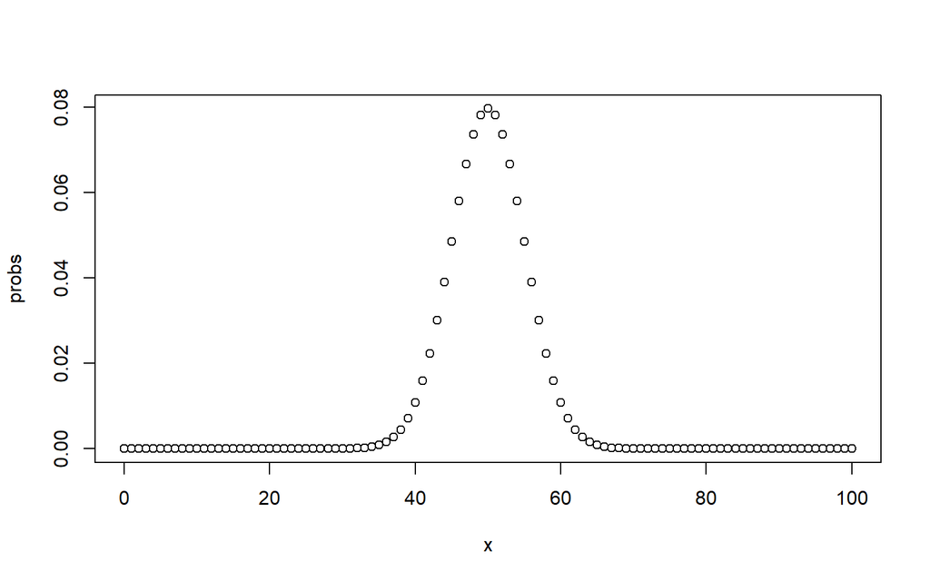

```r
#definition of the binomial
x=seq(0,100,by=1)
probs=dbinom(x=seq(0,100,by=1), size=100, prob=0.5)

#it's discrete but if we increase n it tends to a continuous trend
plot(x, probs)
```

## Student’s T distribution

T has a *Student’s T distribution* with $\nu$ degrees of freedom

$$T\thicksim t_\nu \\
E(T)=0 \\
V(T)=\frac{v}{v-2}$$

Note that if $\nu$ is large enough $T\approx Z$

If we have a set of random variables $X_1 , X_2 , \dots , X_n$, each one distributes Normal with parameters $\mu$ and $\sigma^2$

If we sum them up we obtain another random variable on this case we define the *sample mean estimator* as

$$\bar
X=\frac{1}{n}\sum_{i=1}^{n}X_i$$
and the sample variance is given by

$$S^2=\frac{1}{n-1}\sum_{i=1}^{n}(X_i-\bar
X)^2$$
Then,

$$T= \frac{ \bar X - \mu}{ \sqrt{S^2/n}}
\thicksim t_{n-1}$$
Usually we are compelled to use a Tstudent distribution instead of a normal distribution, because our sample is small and we don’t know the true population standard deviation $\sigma$ this, gives a extra uncertainty because we are estimating the variability of the data with the sample SD $s$. a T student distribution will converge to a normal distributions as n grows. Graphically this means a t students has fatter tails.